# Лингвистическое картографирование

Г. Мороз  
Презентация доступна: tinyurl.com/ya865px5

2018/11/22, НИУ ВШЭ СПб

# What can you do with linguistic maps?

1. visualise some languoids (see (Nordhoff and Hammarström (2011))) under investigation (**language maps**)
2. visualise the distribution of the linguistic feature(s) in SPACE (**linguistic maps**)
3. visualise the distribution of the linguistic feature(s) in SPACE + TIME
4. visualise the relation between some languoid according to some linguistic feature in SPACE (+ TIME)
5. visualise the interaction between some linguistic feature in SPACE (+ TIME) according to some set of langoids
6. investigate language stereotypes
7. simulate spread of the linguistic features in SPACE (+TIME)

# 1. Visualise languoids

- [`lingtypology`](https://github.com/ropensci/lingtypology) can visulise any language from [Glottolog database](http://glottolog.org/)
- dialect information (and coordinates) should be provided by user

# 1. Visualise languoids: Sign languages

[interactive chart not shown]

# 1. Visualise languoids: Circassian dialects

[interactive chart not shown]

# 2. Linguistic features + SPACE: Categorical variable

[interactive chart not shown]

# 2. Linguistic features + SPACE: Numeric variable

[interactive chart not shown]

# 2. Linguistic features + SPACE: *moon* in SL

[interactive chart not shown]

# 2. Linguistic features + SPACE: Tricks for static maps

[interactive chart not shown]

# 2. Linguistic features + SPACE: Tricks for static maps

[interactive chart not shown]

# 3. Linguistic features + SPACE + TIME: Change in the knowledge of Russian

[interactive chart not shown]

Data collected by [Nina Dobrushina, et. al.](https://multidagestan.com/team)

# 3. Linguistic features + SPACE + TIME: Change in the knowledge of Russian

[interactive chart not shown]

Data collected by [Nina Dobrushina, et. al.](https://multidagestan.com/team)

# 3. Linguistic features + SPACE + TIME: Change in the knowledge of Russian and Lak

[interactive chart not shown]

Data collected by [Nina Dobrushina, et. al.](https://multidagestan.com/team)

# 3. Linguistic features + SPACE + TIME: Problems so far?

There is no (as far as I know) a good solution in R for geting data from Raster pictures. That make complicated work with old maps.

- old roads could explain complex contact situations
- old maps could show old settlement patterns
- …
- it is also a problem for modern maps

# 4. Relation between some languoids: Logistic regression

[interactive chart not shown]

# 4. Relation between some languoids: Kernal Density contourplot

[interactive chart not shown]

# 4. Relation between some languoids: Kernal Density contourplot

[interactive chart not shown]

# 4. Relation between some languoids: External polygons

[interactive chart not shown]

Data created by [Niko Partanen](https://github.com/nikopartanen/language_maps).

# 4. Relation between some languoids: Heeringa and Hinskens (2015)

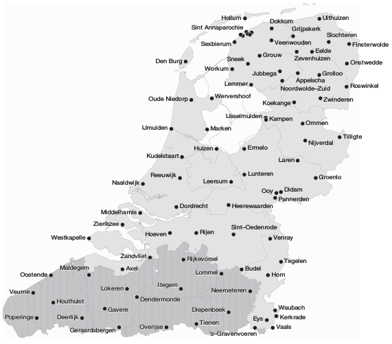

# 4. Relation between some languoids: Heeringa and Hinskens (2015)

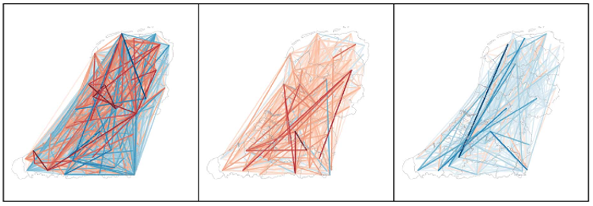

Convergence/divergence between dialects measured on the basis of all sound changes (left), on the basis of sound changes which cause dialects to converge to standard Dutch (center) and on the basis of sound changes which cause dialects to diverge from standard Dutch (right). Red lines indicate convergence and blue lines indicate divergence; the intensity represents the degree of convergence (red shade) or divergence (blue shade).

# 4. Relation between some languoids: Heeringa and Hinskens (2015)

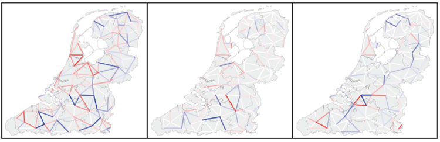

Convergence/divergence between neighboring dialects measured on the basis of all sound changes (left), on the basis of sound changes which cause dialects to converge to standard Dutch (center) and on the basis of sound changes which cause dialects to diverge from standard Dutch (right). Red lines indicate convergence and blue lines indicate divergence; the intensity represents the degree of convergence (red shade) or divergence (blue shade).

# 5. Relation between some linguistic features in SPACE (+ TIME): Strokes

[interactive chart not shown]

It also possible to converge multiple features to one.

# 5. Relation between some linguistic features in SPACE (+ TIME): What if we have 100 features?

- Multiple features requere a database…
- that allow to work with complex query…
- Methods for dimention reduction (PCA/MCA, MDS, etc.) allow to cluster features and define the interesting one
- But anyway it is linguists who need to decide whether feature or feature combination is *ineteresting* or not.

# 5. Relation between some linguistic features in SPACE (+ TIME): Is space important for feature destribution?

It depends. But how to measure it?

- Spatial autocorrelation:
  - Moran’s I (Moran (1948), Odland (1988)). The test statistic, I, ranges in value from negative to positive 1, with 0 indicating random spatial distribution. Positive values indicate a tendency towards clustering of similar values, while negative values indicate a tendency towards dispersion of similar values.
  - Getis-Ord G~i* (Ord and Getis (1995)). This measure tests for local spatial autocorrelation, which asks whether each location is part of a significant high or low value cluster with its neighbors.

See (Tamminga (2013), Grieve, Speelman, and Geeraerts (2013)) for linguistic usage.

Restriction: good dialectal data. Garbage in — garbage out.

# 6. Perceptual Dialectology

It looks like it started from works (Preston (1982) and Gould and White (1986)). The field of perceptual dialectology have developed a huge list of instruments:

- Hand-drawn Map Task
- Dialect Difference Rating Task
- Dialect Classiﬁcation Task
- …

# 7. simulate spread of the linguistic features in SPACE (+TIME)

It is the only field, where linguistics try to do prediction. It is not homogeneous. Here are some works:

- Abrams and Strogatz (2003)
- Grieve, Speelman, and Geeraerts (2010)
- Kretzschmar, Juuso, and Bailey (2014)

# 8. Conclusions

- There is a lot of work on linguistic mapping that could be automated
- Te open Science and standards for linguistic mapping will make - our life easear - our researchs more comparable - our work more reproducible

# Thank you!

G. Moroz (agricolamz@gmail.com)

Link to this presentation: goo.gl/LUZYev

# Referenses

Abrams, D. M., and S. H. Strogatz. 2003. “Linguistics: Modelling the Dynamics of Language Death.” *Nature* 424 (6951). Nature Publishing Group: 900–900.

Gould, P., and R. White. 1986. *Mental Maps*. Boston: Allen & Unwin.

Grieve, J., D. Speelman, and D. Geeraerts. 2010. “The Emergence of Regional Linguistic Variation: A Computer Simulation.” NWAV.

———. 2013. “A Multivariate Spatial Analysis of Vowel Formants in American English.” *Journal of Linguistic Geography* 1 (1). Cambridge University Press: 31–51.

Heeringa, W., and F. Hinskens. 2015. “Dialect Change and Its Consequences for the Dutch Dialect Landscape. How Much Is Due to the Standard Variety and How Much Is Not?” *Journal of Linguistic Geography* 3 (1). Cambridge University Press: 20–33.

Kretzschmar, W. A., I. Juuso, and C. Th. Bailey. 2014. “Computer Simulation of Dialect Feature Diffusion.” *Journal of Linguistic Geography* 2 (1). Cambridge University Press: 41–57.

Moran, P. A. P. 1948. “The Interpretation of Statistical Maps.” *Journal of the Royal Statistical Society. Series B (Methodological)* 10 (2): 243–51.

Nordhoff, S., and H. Hammarström. 2011. “Glottolog/Langdoc: Defining Dialects, Languages, and Language Families as Collections of Resources.” In *Proceedings of the First International Conference on Linked Science-Volume 783*, 53–58. CEUR-WS. org.

Odland, J. D. 1988. *Spatial Autocorrelation*. Beverly Hills, CA: Sage Publications.

Ord, J. K., and A. Getis. 1995. “Local Spatial Autocorrelation Statistics: Distributional Issues and an Application.” *Geographical Analysis* 27 (4). Wiley Online Library: 286–306.

Preston, D. R. 1982. “Perceptual Dialectology: Mental Maps of United States Dialects from a Hawaiian Perspective.” *Working Papers in Linguistics* 14 (2): 5–49.

Tamminga, M. 2013. “Phonology and Morphology in Dutch Indefinite Determiner Syncretism: Spatial and Quantitative Perspectives.” *Journal of Linguistic Geography* 1 (2). Cambridge University Press: 115–24.